# Project Title: Insights into YouTube Channel Performance - A Data-Driven Approach

Phan Chenh

## Introduction

The dataset analyzed was collected by *Nidula Elgiriyewithana* and can be downloaded from Kaggle platform. You can create an account and log in to Kaggle to download the dataset (a .csv file) and access the data dictionary.

This dataset unveils the statistics of the most subscribed YouTube channels and offers a perfect avenue to analyze and gain valuable insights from the luminaries of the platform.

Dataset link: https://www.kaggle.com/datasets/nelgiriyewithana/global-youtube-statistics-2023

## Data loading, overview and set up

Install packages

```
install.packages("ggplot2")
install.packages("ggthemes")
install.packages("gridExtra")
install.packages("dplyr")
install.packages("reshape2")
install.packages("scales")
install.packages("maps")
```

Load libraries

```r
library(ggplot2)
library(ggthemes)
library(gridExtra)
library(dplyr)
library(reshape2)
library(scales)
library(maps)
```

Setting up a plotting theme to make all graphs visually consistent and aesthetically

```r
project_theme <- theme_few() +
  theme(plot.title = element_text(size = 12, color = "darkblue")) +
  theme(plot.margin = margin(10,30,10,30))
```

Load the main data

```r
data <- read.csv("Global YouTube Statistics.csv", header = T)
```

Using *str()* to analyze the data

```r
str(data)
```

Using *summary()* to analyze the data

```r
summary(data)
```

```r
head(data)
```

### Initial transformations

```r
# Convert character variables to factors
data <- within(data, {
  category <- as.factor(category)
  Country <- as.factor(Country)
  Abbreviation <- as.factor(Abbreviation)
  channel_type <- as.factor(channel_type)
  created_month <- as.factor(created_month)
  created_year <- as.factor(created_year)
  created_date <- as.factor(created_date)
})

# Counting the missing values in each variable
count_missing <- function(df){
  sapply(df, FUN = function(col) sum(is.na(col)))
}
nacounts <- count_missing(data)
hasNA = which(nacounts > 0)
nacounts[hasNA]
```

```
##                        video_views_rank                            country_rank
##                                       1                                     116
##                       channel_type_rank        video_views_for_the_last_30_days
##                                      33                                      56
##            subscribers_for_last_30_days Gross.tertiary.education.enrollment....
##                                     337                                     123
##                              Population                       Unemployment.rate
##                                     123                                     123
##                        Urban_population                                Latitude
##                                     123                                     123
##                               Longitude
##                                     123
```

data has 995 rows, it is safe to drop rows with NAs in the “video_views_rank” but not the others. However, there are columns which might have the missing values are all in the same rows. Let’s check it before we decide to drop any rows.

```r
# Checking if missing values are from the same rows
summary(data[is.na(data$Population),
             c("Latitude", "Unemployment.rate", "Urban_population", "Population", "Gross.tertiary.education.enrollment....", "country_rank", "Longitude")])
```

```
##     Latitude   Unemployment.rate Urban_population   Population
##  Min.   : NA   Min.   : NA       Min.   : NA      Min.   : NA
##  1st Qu.: NA   1st Qu.: NA       1st Qu.: NA      1st Qu.: NA
##  Median : NA   Median : NA       Median : NA      Median : NA
##  Mean   :NaN   Mean   :NaN       Mean   :NaN      Mean   :NaN
##  3rd Qu.: NA   3rd Qu.: NA       3rd Qu.: NA      3rd Qu.: NA
##  Max.   : NA   Max.   : NA       Max.   : NA      Max.   : NA
##  NA's   :123   NA's   :123       NA's   :123      NA's   :123
##  Gross.tertiary.education.enrollment....  country_rank      Longitude
##  Min.   : NA                             Min.   :   1.0   Min.   : NA
##  1st Qu.: NA                             1st Qu.:   2.0   1st Qu.: NA
##  Median : NA                             Median :   3.5   Median : NA
##  Mean   :NaN                             Mean   : 478.2   Mean   :NaN
##  3rd Qu.: NA                             3rd Qu.: 129.8   3rd Qu.: NA
##  Max.   : NA                             Max.   :3305.0   Max.   : NA
##  NA's   :123                             NA's   :115      NA's   :123
```

```r
summary(data[is.na(data$channel_type_rank) & is.na(data$video_views_for_the_last_30_days),
             c("Population", "subscribers_for_last_30_days", "video_views_rank")])
```

```
##    Population        subscribers_for_last_30_days video_views_rank
##  Min.   :5.704e+06   Min.   :1.00                 Min.   :3612215
##  1st Qu.:4.011e+07   1st Qu.:1.00                 1st Qu.:4057898
##  Median :1.046e+08   Median :2.00                 Median :4057944
##  Mean   :3.033e+08   Mean   :2.50                 Mean   :3976488
##  3rd Qu.:1.909e+08   3rd Qu.:2.75                 3rd Qu.:4057944
##  Max.   :1.366e+09   Max.   :6.00                 Max.   :4057944
##  NA's   :17          NA's   :15                   NA's   :1
```

Further checking with other columns, we can see that there is missing data happened in “subscribers_for_last_30_days” and “channel_type_rank” as well. In this case, we will omit 12 rows as 1 NAs is in “video_views_rank” column and 11 NAs in which NAs “subscribers_for_last_30_days” intersect with NAs “channel_type_rank”, “video_views_for_the_last_30_days” and “Population” as other variables also contain the same NAs rows on themselves.

```r
# Remove rows that have NAs in the same rows
data_cleaned <- subset(data, !(is.na(video_views_rank)))

data_cleaned <- subset(data_cleaned, !(is.na(subscribers_for_last_30_days) & is.na(channel_type_rank) & is.na(video_views_for_the_last_30_days) & is.na(Population)))
nrow(data)
```

```
## [1] 995
```

```r
nrow(data_cleaned)
```

```
## [1] 983
```

After remove a few NAs rows, we can see that the left missing values are all happened in numerical variables. We will replace them with the median or an appropriate estimate for values are missing randomly, and for values are missing systematically we will convert them to categorical and replace them with zero and add a masking variable.

```r
# Replacing missing values with median
median_country_rank <- median(data_cleaned$country_rank, na.rm = TRUE)
data_cleaned <- data_cleaned %>%
  mutate(new_country_rank = ifelse(is.na(country_rank), median_country_rank, country_rank))

median_channel_type_rank <- median(data_cleaned$channel_type_rank, na.rm = TRUE)
data_cleaned <- data_cleaned %>%
  mutate(new_channel_type_rank = ifelse(is.na(channel_type_rank), median_channel_type_rank, channel_type_rank))

median_video_views_for_the_last_30_days <- median(data_cleaned$video_views_for_the_last_30_days, na.rm = TRUE)
data_cleaned <- data_cleaned %>%
  mutate(new_video_views_for_the_last_30_days = ifelse(is.na(video_views_for_the_last_30_days), median_video_views_for_the_last_30_days, video_views_for_the_last_30_days))

median_subscribers_for_last_30_days <- median(data_cleaned$subscribers_for_last_30_days, na.rm = TRUE)
data_cleaned <- data_cleaned %>%
  mutate(new_subscribers_for_last_30_days = ifelse(is.na(subscribers_for_last_30_days), median_subscribers_for_last_30_days, subscribers_for_last_30_days))

median_Latitude <- median(data_cleaned$Latitude, na.rm = TRUE)
data_cleaned <- data_cleaned %>%
  mutate(new_Latitude = ifelse(is.na(Latitude), median_Latitude, Latitude))

median_Longitude <- median(data_cleaned$Longitude, na.rm = TRUE)
data_cleaned <- data_cleaned %>%
  mutate(new_Longitude = ifelse(is.na(Longitude), median_Longitude, Longitude))
```

```r
# Convert missing values to categorical and replace them with zero
data_cleaned$Population <- ifelse(is.na(data_cleaned$Population), 0, data_cleaned$Population)

data_cleaned$Gross.tertiary.education.enrollment.... <- ifelse(is.na(data_cleaned$Gross.tertiary.education.enrollment....), 0, data_cleaned$Gross.tertiary.education.enrollment....)

data_cleaned$Urban_population <- ifelse(is.na(data_cleaned$Urban_population), 0, data_cleaned$Urban_population)

data_cleaned$Unemployment.rate <- ifelse(is.na(data_cleaned$Unemployment.rate), 0, data_cleaned$Unemployment.rate)


data_cleaned <- within(data_cleaned, {
  Population <- as.factor(Population)
  Gross.tertiary.education.enrollment.... <- as.factor(Gross.tertiary.education.enrollment....)
  Urban_population <- as.factor(Urban_population)
  Unemployment.rate <- as.factor(Unemployment.rate)
  })
```

Let’s have a look if there is any NAs data

```r
apply(is.na(data_cleaned), 2, sum)
```

```
##                                    rank                                Youtuber
##                                       0                                       0
##                             subscribers                             video.views
##                                       0                                       0
##                                category                                   Title
##                                       0                                       0
##                                 uploads                                 Country
##                                       0                                       0
##                            Abbreviation                            channel_type
##                                       0                                       0
##                        video_views_rank                            country_rank
##                                       0                                     105
##                       channel_type_rank        video_views_for_the_last_30_days
##                                      21                                      44
##                 lowest_monthly_earnings                highest_monthly_earnings
##                                       0                                       0
##                  lowest_yearly_earnings                 highest_yearly_earnings
##                                       0                                       0
##            subscribers_for_last_30_days                            created_year
##                                     325                                       0
##                           created_month                            created_date
##                                       0                                       0
## Gross.tertiary.education.enrollment....                              Population
##                                       0                                       0
##                       Unemployment.rate                        Urban_population
##                                       0                                       0
##                                Latitude                               Longitude
##                                     112                                     112
##                        new_country_rank                   new_channel_type_rank
##                                       0                                       0
##    new_video_views_for_the_last_30_days        new_subscribers_for_last_30_days
##                                       0                                       0
##                            new_Latitude                           new_Longitude
##                                       0                                       0
```

Most of the columns do not have any NAs. The ones that do we already change to new columns above called “new_country_rank”, “new_channel_type_rank”, “new_video_views_for_the_last_30_days”, “new_subscribers_for_last_30_days”, “new_Longitude” and “new_Latitude”

### Gain valuable insight: top channels YouTube and what sets them apart from others

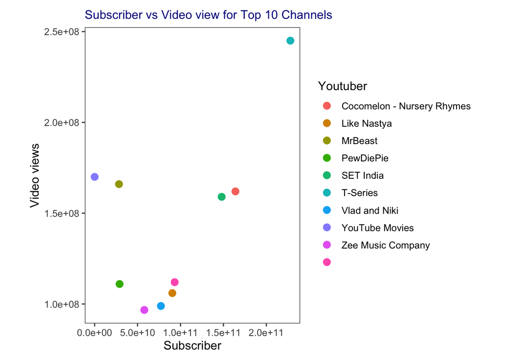

```r
# Select the top 10 channels by their sum
top10_channels <- data_cleaned %>%
  arrange(desc(sum(subscribers))) %>%
  head(10)

# Chose influence factors
influence_factors <- top10_channels %>%
  select(Youtuber, Country, channel_type, subscribers, video.views, video_views_rank, uploads, new_country_rank, new_channel_type_rank)

# Create a scatter plot
p1 <- ggplot(influence_factors, aes(x = video.views, y = subscribers, color = Youtuber)) +
  geom_point(size = 3)+
  labs(title = "Subscriber vs Video view for Top 10 Channels",
       x = "Subscriber",
       y = "Video views") + project_theme
p1
```

```r
# Find out YouTube's channel type
youtube_channel <- influence_factors[, c("Youtuber", "channel_type")]
youtube_channel
```

|  | Youtuber | channel_type |
| --- | --- | --- |
| 1 | T-Series | Music |
| 2 | YouTube Movies | Games |
| 3 | MrBeast | Entertainment |
| 4 | Cocomelon - Nursery Rhymes | Education |
| 5 | SET India | Entertainment |
| 6 | \xfd\xfd\xfd Kids Diana Show | Entertainment |
| 7 | PewDiePie | Entertainment |
| 8 | Like Nastya | People |
| 9 | Vlad and Niki | Entertainment |
| 10 | Zee Music Company | Music |

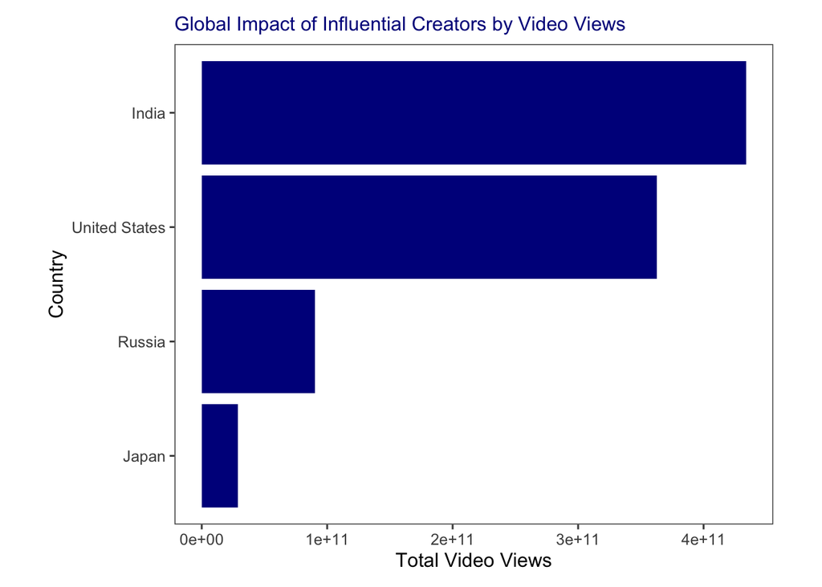

```r
# Identify influential YouTube creators from different countries and analyze their impact on a global scale
country_impact <- top10_channels %>%
  group_by(Country) %>%
  summarise(total_subscribers = sum(subscribers),
            total_views = sum(video.views)) %>%
  arrange(desc(total_subscribers))

p2 <- ggplot(country_impact, aes(x = reorder(Country, total_views), y = total_views)) +
  geom_bar(stat = "identity", fill = "darkblue") +
  coord_flip() +
  labs(title = "Global Impact of Influential Creators by Video Views",
       x = "Country",
       y = "Total Video Views") + project_theme

p2
```

Insights:

The channel types that lead are Music, Education, and Entertainment, highlighting a strong audience preference for these categories.

Some channels achieve higher views but fewer subscribers (and vice versa), suggesting different engagement strategies or content types.

### Discover the most popular channel type and upload frequencies that resonate with audiences

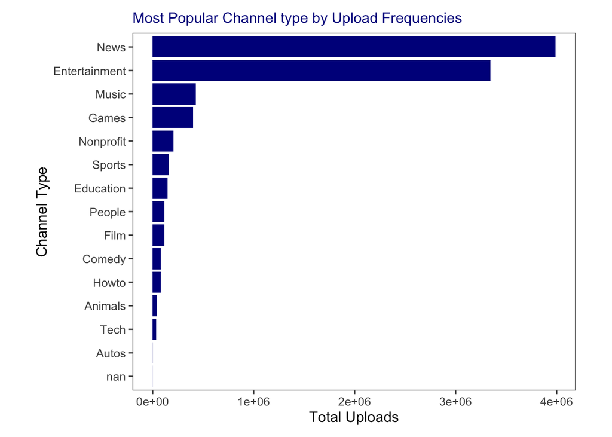

```r
# Grouping and summarizing by channel type
channel_sum <- data_cleaned %>%
  group_by(channel_type) %>%
  summarise(total_uploads = sum(uploads))


# Create a bar plot
p3 <- ggplot(channel_sum, aes(x = reorder(channel_type, total_uploads), y = total_uploads)) +
  geom_bar(stat = "identity", fill = "darkblue") +
  coord_flip() +
  labs(title = "Most Popular Channel type by Upload Frequencies",
       x = "Channel Type",
       y = "Total Uploads") + project_theme
p3
```

Insights:

News and Entertainment channels have the highest upload frequencies, but high frequency does not necessarily translate to higher subscribers or views.

Entertainment channels seem to correlate well with high engagement, unlike News channels, which show a mismatch between upload frequency and engagement.

### Trending topics/ channel type by time

We already have few top channels that we interested in, let’s see how those channels growth after years, are they still popular or out dated?

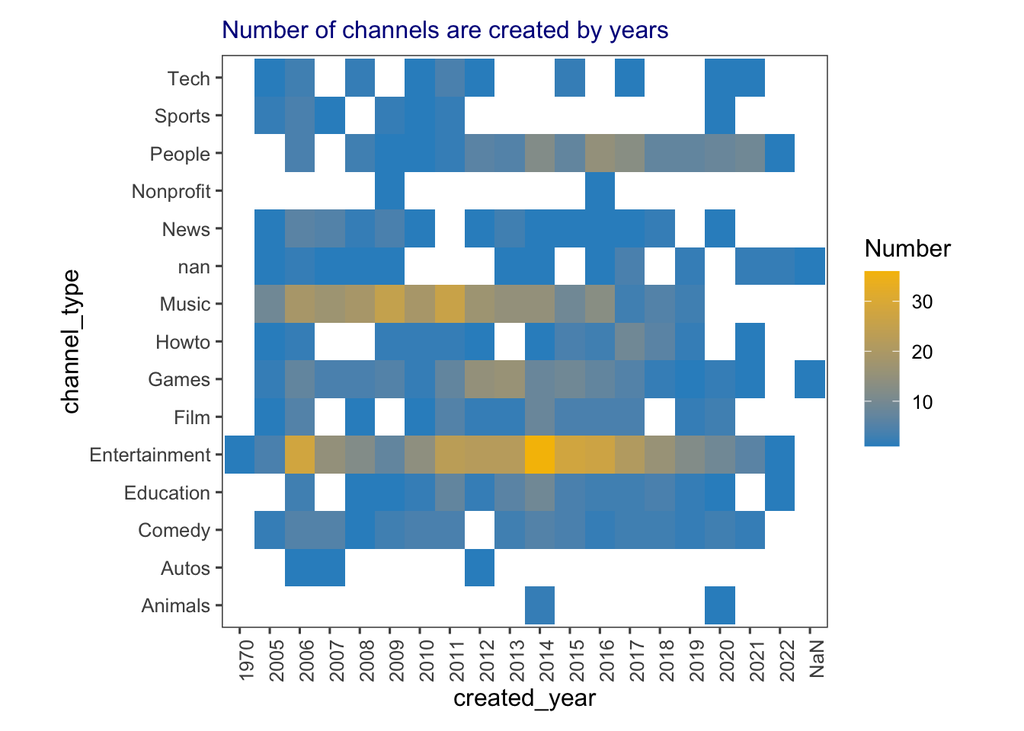

```r
# Create a heatmap
counting <- count(data_cleaned, created_year, channel_type)
p4 <- ggplot(data = counting, aes(x = created_year, y = channel_type, fill = n)) + geom_tile(mapping = aes(fill = n )) + scale_fill_gradient(high = "#F6BE00", low = "#3090C7") +
  labs(
    title = "Number of channels are created by years ",
    fill = "Number"
  ) + project_theme +
  theme(axis.text.x = element_text(angle = 90, hjust = 1))
p4
```

Insights:

Entertainment channels have longevity and consistent creation over the years, showing strong and sustained demand.

Music channels also maintain a presence but not as consistently as Entertainment.

### Explore the correlation between channel performance and estimated earnings

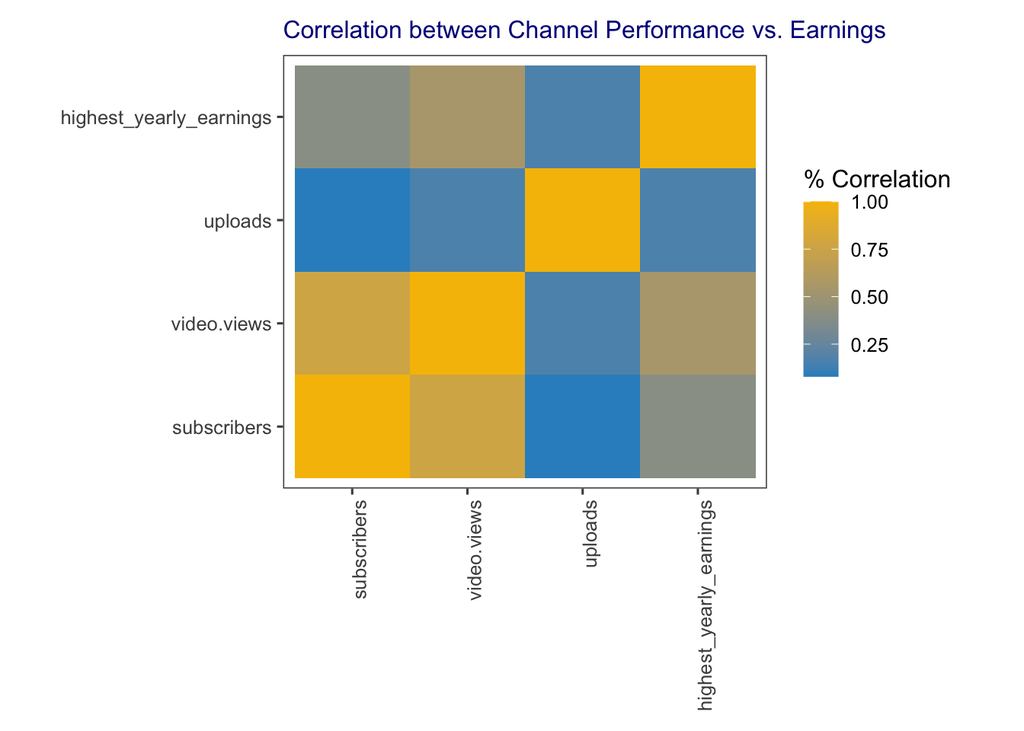

```r
# Calculate correlation coefficients
correlation <- cor(data_cleaned[, c("subscribers", "video.views", "uploads", "highest_yearly_earnings")])

# Create a heatmap
correlation_data <- melt(correlation)

p5 <-ggplot(data = correlation_data, aes(x = Var1, y = Var2, fill = value)) +
  geom_tile() +
  scale_fill_gradient(high = "#F6BE00", low = "#3090C7") +
  labs(
    title = "Correlation between Channel Performance vs. Earnings",
    fill = "% Correlation"
  ) + project_theme +
  theme(axis.text.x = element_text(angle = 90, hjust = 1),
        axis.title.x = element_blank(),
        axis.title.y = element_blank())

p5
```

Insights:

Video views have the highest correlation with earnings, more so than upload frequency or subscriber count.

Subscribers also correlate with views, indicating that a larger subscriber base can drive higher viewership but is not the sole factor for earnings.

### Geography information

Plot the highest yearly earnings by country to have an understanding of where YouTubers earn the most.

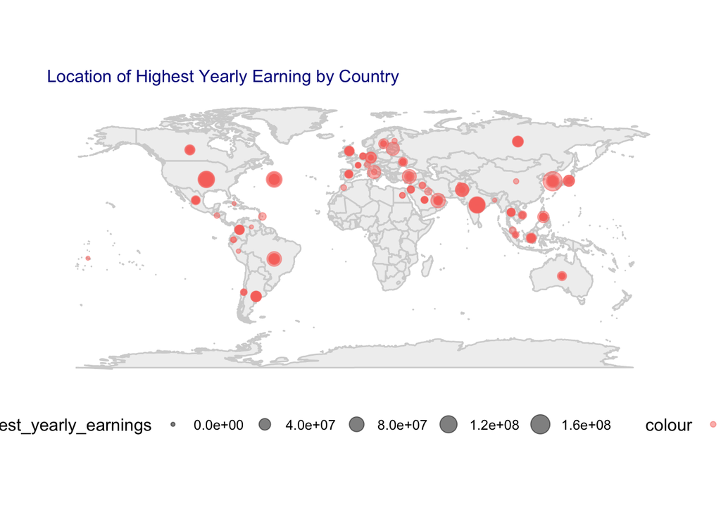

```r
## Plot a map
# Create a custom theme for the map
project_map_theme <- project_theme +
  theme(panel.grid = element_blank(),
        panel.border = element_blank(),
        legend.position = "bottom",
        legend.direction = 'horizontal',
        axis.title.x = element_blank(),
        axis.text.x = element_blank(),
        axis.ticks.x = element_blank(),
        axis.title.y = element_blank(),
        axis.text.y = element_blank(),
        axis.ticks.y = element_blank())

# Create the map plot
p7 <- ggplot(data_cleaned) +
  geom_polygon(map_data("world"), mapping = aes(x = long, y = lat, group = group), fill = "#F0F0F0", colour = "lightgray") +
  geom_point(aes(x = new_Longitude, y = new_Latitude, size = highest_yearly_earnings, color = "pink"), alpha = 0.5) +
  coord_quickmap() +
  ggtitle("Location of Highest Yearly Earning by Country") +
  project_map_theme
p7
```

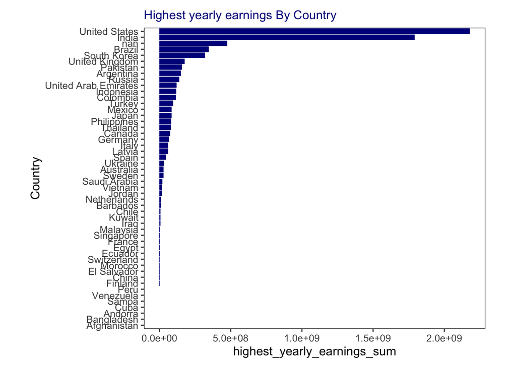

```r
earning_by_country <- data_cleaned %>%
  group_by(Country) %>%
  summarise(
    highest_yearly_earnings_mean = mean(highest_yearly_earnings),
    highest_yearly_earnings_sum = sum(highest_yearly_earnings)) %>%
  arrange(desc(highest_yearly_earnings_sum))

# Create a bar plot
p6 <- ggplot(earning_by_country, mapping = aes(x = reorder(Country, highest_yearly_earnings_sum), y = highest_yearly_earnings_sum)) +
  geom_bar(stat = "identity", fill = "darkblue") +
  ggtitle("Highest yearly earnings By Country") +
  coord_flip() +
  labs(x = "Country") +
  theme(axis.text.y = element_text(size = rel(0.8))) +
  project_theme
p6
```

According to the plot (p6) and (p7) above, there are some clear issues with the data, there is a “nan” country take third place in bar plot. However, as we already treat it as a variable so we will leave it as it is for now.

Insights:

The United States and India lead in yearly earnings, indicating strong YouTube markets in these regions.

Brazil and Korea are emerging markets but with a noticeable gap compared to the US and India.